# Statistiline modelleerimine 2017

## 5.2 Histogramm

Histogramm on sobilik arvtunnuse jaotuse visualiseerimiseks. Histogrammi kuvamiseks on ggplotis käsklus `geom_histogramm(...)`. Histogrammi y-telg on vaikimisi sagedus, ent selle võib kirjutada soovi korral üle. Histogrammil on võimalik seadistada vahemike laiust või hulka (argumendid `bin` ja `binwidth`).

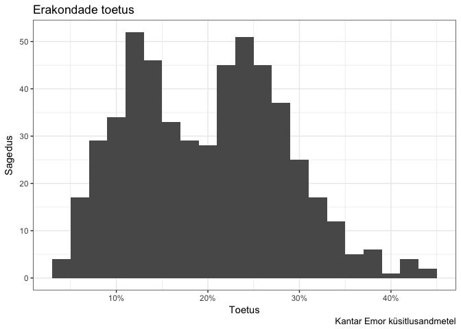

```r
df %>%
  ggplot() +
  geom_histogram(aes(support), binwidth=0.02) +
  scale_x_continuous(labels=scales::percent) +
  labs(x="Toetus", y="Sagedus", title="Erakondade toetus",caption="Kantar Emor küsitlusandmetel") +
  theme_bw()
```

Iga erakonna kohta eraldi joonise kuvamiseks võime kasutada käsklusi `facet_wrap(~party)` või `facet_grid(~party)`.

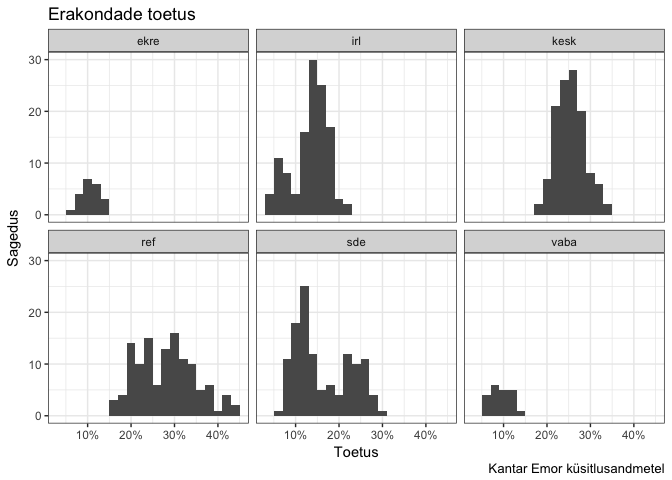

```r
df %>%
  ggplot() +
  geom_histogram(aes(support), binwidth=0.02) +
  facet_wrap(~party) +
  scale_x_continuous(labels=scales::percent) +
  labs(x="Toetus", y="Sagedus", title="Erakondade toetus",caption="Kantar Emor küsitlusandmetel") +
  theme_bw()
```

## 5.3 Karpdiagramm ja viiuldiagramm

Arvtunnuse jaotuse näitamiseks on võimalik kasutada lisaks histogrammile karpdiagrammi `geom_boxplot(...)` ja viiuldiagrammi `geom_violin(...)`. Karpdiagrammile võib hajutatult kuvada ka üksikud vaatlused käsklusega `geom_jitter(...)` (mõistlik on muuta kuvatud vaatlused läbipaistvaks argumendiga `alpha` ning koondada need kitsamale alale argumendiga `width`).

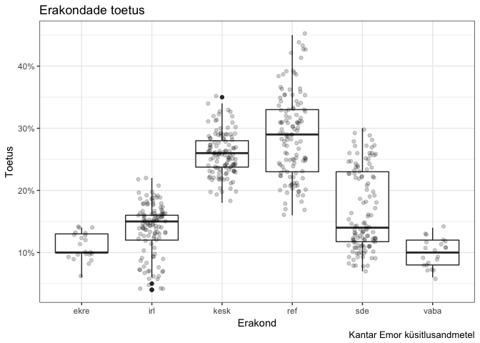

```r
df %>%
  ggplot() +
  geom_boxplot(aes(party,support)) +
  geom_jitter(aes(party,support), alpha=0.2, width=0.2) +
  scale_y_continuous(labels=scales::percent) +
  labs(x="Erakond", y="Toetus", title="Erakondade toetus",caption="Kantar Emor küsitlusandmetel") +
  theme_bw()
```

Viiuldiagramm annab veelgi täpsema ülevaate jaotusest. Viiuldiagrammile võib lisada kvantiilide jooned argumendiga `draw_quantiles`.

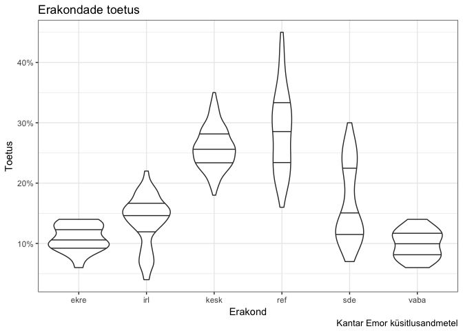

```r
df %>%
  ggplot() +
  geom_violin(aes(party,support), draw_quantiles=c(.25,.5,.75)) +
  scale_y_continuous(labels=scales::percent) +
  labs(x="Erakond", y="Toetus", title="Erakondade toetus",caption="Kantar Emor küsitlusandmetel") +
  theme_bw()
```

## 5.4 Hajuvusdiagramm

Hajuvusdiagrammi kasutatakse kahe arvtunnuse omavahelise seose visualiseerimiseks.

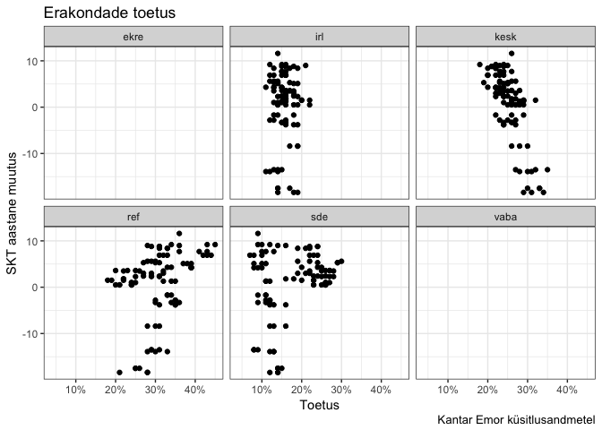

```r
df %>%
  ggplot() +
  geom_point(aes(support,gdpgr_yearly)) +
  scale_x_continuous(labels=scales::percent) +
  facet_wrap(~party) +
  labs(x="Toetus", y="SKT aastane muutus", title="Erakondade toetus",caption="Kantar Emor küsitlusandmetel") +
  theme_bw()
```

## 5.5 Joondiagramm

Joondiagramm, nagu hajuvusdiagrammgi, on sobilik kahe arvtunnuse omavahelise seose visualiseerimiseks. Joondiagrammi kasutatakse rohkem siis, kui üks tunnustest on seotud ajaga.

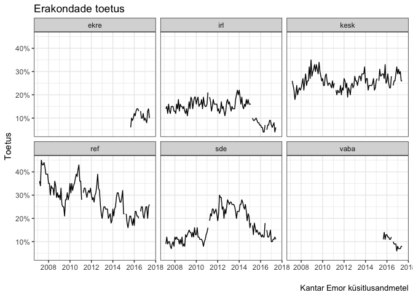

```r
df %>%
  ggplot() +
  geom_line(aes(as.Date(date),support)) +
  scale_y_continuous(labels=scales::percent) +
  facet_wrap(~party) +
  labs(x="", y="Toetus", title="Erakondade toetus",caption="Kantar Emor küsitlusandmetel") +
  theme_bw()
```

## 5.5 Likerti skaala

Küsitlustes kasutatakse tihti likerti skaalasid, mida visualiseeritakse enamasti tulpdiagrammi abil (skaala on protsentides).

Kasutame näiteks EP 2014 andmestikust usalduse tunnust.

```r
library(reshape2)
usaldus = paneel %>%
  mutate(enne = case_when(!(t1.evalimiste.usaldus %in% 97:98) ~ t1.evalimiste.usaldus),
         parast = case_when(!(t2.evalimiste.usaldus %in% 97:98) ~ t2.evalimiste.usaldus)) %>%
  select(enne,parast) %>%
  melt() %>%
  na.omit() %>%
  group_by(variable,value = as.factor(value)) %>%
  summarise(count = n()) %>%
  mutate(pc = count/sum(count[variable==variable]))

usaldus
```

```
# A tibble: 22 x 4
# Groups:   variable [2]
   variable  value count         pc
     <fctr> <fctr> <int>      <dbl>
 1     enne      0   185 0.15651438
 2     enne      1    17 0.01438240
 3     enne      2    29 0.02453469
 4     enne      3    44 0.03722504
 5     enne      4    32 0.02707276
 6     enne      5    85 0.07191201
 7     enne      6    42 0.03553299
 8     enne      7    88 0.07445008
 9     enne      8   185 0.15651438
10     enne      9   176 0.14890017
# ... with 12 more rows
```

Graafime tulemused tulpdiagrammina.

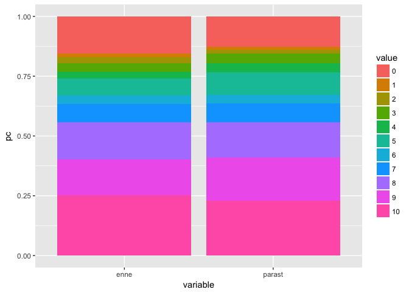

```r
usaldus %>%
  ggplot() +
  geom_col(aes(variable,pc,fill=value))
```

Antud joonist saab muuta loetavamaks vahetades värviskaalat, pöörates joonise telgi, muutes telgede nimesid jne.

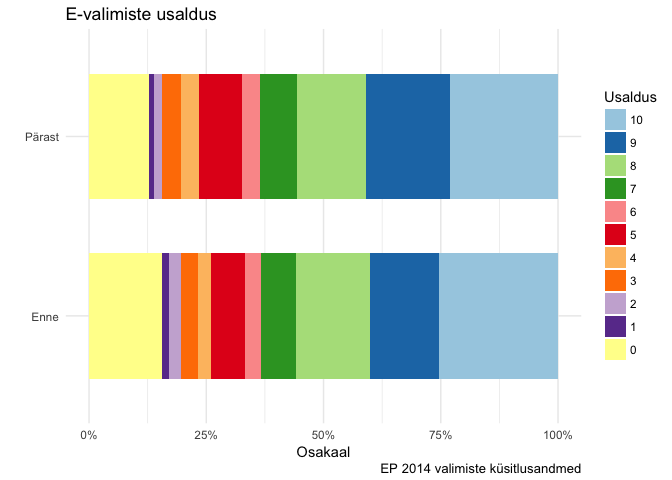

```r
usaldus %>%
  ggplot() +
  geom_col(aes(variable,pc,fill=reorder(value,desc(value))),width=0.7) +
  scale_fill_brewer(name="Usaldus",palette="Paired") +
  scale_y_continuous(labels=scales::percent) +
  scale_x_discrete(labels=c("Enne","Pärast")) +
  labs(x="", y="Osakaal", title="E-valimiste usaldus",caption="EP 2014 valimiste küsitlusandmed") +
  coord_flip() +
  theme_minimal()
```

Alternatiiv on kasutada spetsiaalset likerti skaalade visualiseerimiseks mõeldud funktsiooni `likert(...)` paketist **HH**.

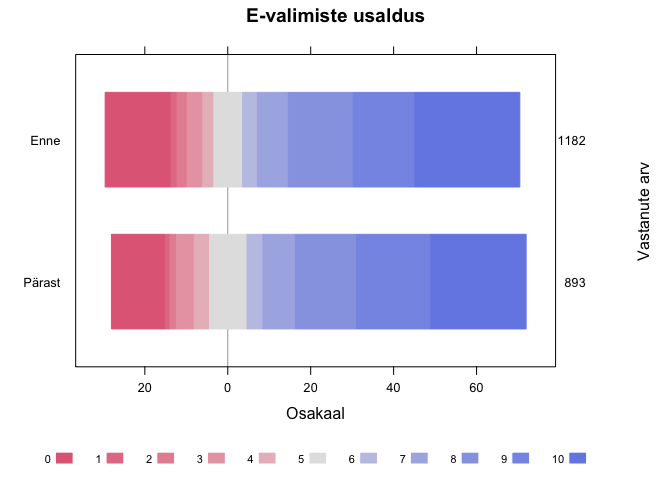

```r
usaldus.2 = usaldus %>%
  dcast(variable ~ value, value.var="count")
rownames(usaldus.2) = c("Enne", "Pärast")

HH::likert(usaldus.2,
           as.percent=T,
           ylab.right="Vastanute arv",
           xlab="Osakaal",
           main="E-valimiste usaldus",
           sub="")
```

# 6 Korrelatsioon

### 6.0.1 Paketid

```r
library(tidyverse)
library(psych)
library(PerformanceAnalytics)
```

### 6.0.2 Andmestik

```r
df = read.csv("https://martenveskimae.github.io/stat-mod/party_dataset.csv")
paneel = read.csv("https://martenveskimae.github.io/stat-mod/ep2014_paneel.csv")
```

## 6.1 Pearsoni korrelatsioonikordaja

Vaatame lähemalt kahe tunnuse vahelist korrelatsiooni, antud juhul Pearsoni korrelatsiooni. Pearsoni korrelatsioon sobib juhul, kui mõlema tunnuse puhul on tegu arvtunnustega.

Pearsoni korrelatsioon on iseloomult lineaarne, st kahe tunnuse vahele üritatakse sobitada lineaarset seost. Matemaatiliselt on korrelatsioon kahe tunnuse kovariatsioon, skaleerituna nende standardhälbega:

$r=\frac{\sum\limits_{i=1}^n(x_{i}-\bar{x})(y_{i}-\bar{y})}{(n-1)s_{x}s_{y}}$

Et anda hinnang korrelatsioonikordaja statistilisele olulisusele, võime arvutada korrelatsiooni t-statistiku väärtuse ja võrrelda seda teoreetilise t-jaotusega.

$t=\frac{r\sqrt{n-2}}{\sqrt{1-r^2}}$

Arvutame käsitsi kahe juhusliku vektori korrelatsiooni (eeldatavalt on korrelatsioon juhuslikkuse tõttu 0). Esmalt tekitame kaks vektorit ning vaatame võimalikku visuaalselt.

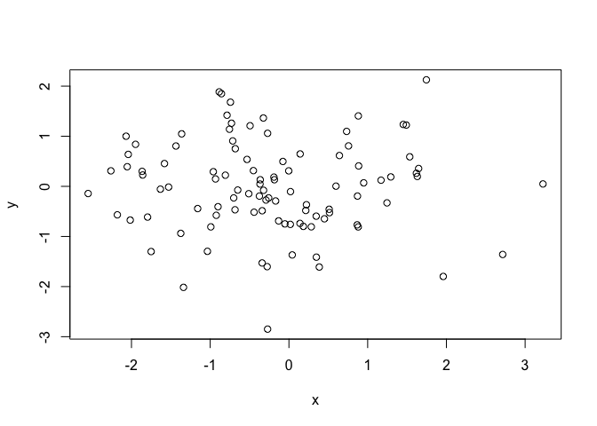

```r
n = 100
x = rnorm(n)
y = rnorm(n)
plot(x,y)
```

Kui kahe vektori vahel on tõepoolest seos, siis on see juhuslik. Hindame seost korrelatsiooni abil.

```r
xbar = mean(x)
ybar = mean(y)
sx = sd(x)
sy = sd(y)

r = sum((x-xbar)*(y-ybar)) / ((n-1)*sx*sy)
r
```

```
[1] -0.0331546
```

Kas tulemus on statistiliselt oluline?

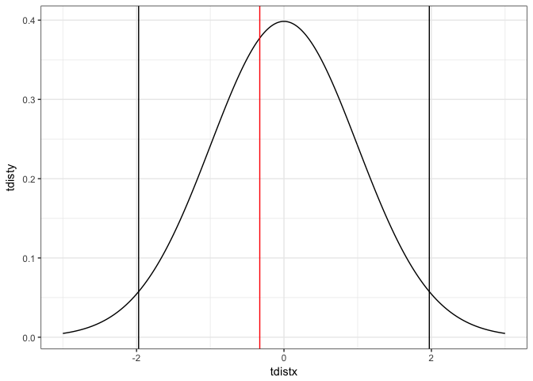

```r
t = (r*sqrt(n-2)) / sqrt(1-r^2) # t-väärtus
p = 2*pt(-abs(t),df=199) # p-väärtus

# Olulisuse visualiseerimine (sama, mis t-testi puhul)
tdistx = seq(-3,3,length=300)
tdisty = dt(tdistx,df=199)
a95 = qt(c(.025, .975), df=199)
ggplot() +
  geom_line(aes(tdistx,tdisty)) +
  geom_vline(xintercept = a95[1]) +
  geom_vline(xintercept = a95[2]) +
  geom_vline(xintercept = t, color="red") +
  theme_bw()
```

Arvutuste tulemusel on:

- korrelatsioon: -0.0331546
- t-skoor: -0.3283944
- p-väärtus: 0.7429588

Õnneks teeb kogu töö ära funktsioon `corr.test(...)` paketist **psych**:

```r
corr.test(cbind(x,y))
```

```
Call:corr.test(x = cbind(x, y))
Correlation matrix
      x     y
x  1.00 -0.03
y -0.03  1.00
Sample Size
[1] 100
Probability values (Entries above the diagonal are adjusted for multiple tests.)
     x    y
x 0.00 0.74
y 0.74 0.00

 To see confidence intervals of the correlations, print with the short=FALSE option
```

Tulemus on sama!

Majandusliku hääletamise teooriast teame, et hääletamine on tihti seotud majanduse käekäiguga - kui majandusel läheb hästi, on koalitsiooni toetus kõrge, kui halvasti, on opositsiooni toetus kõrge. Vaatame näiteks, kuidas on seotud Reformierakonna toetus tööpuuduse, SKT kasvu ja inflatsiooniga.

```r
ref = df %>%
  filter(party == "ref") %>%
  select(support, unemp, gdpgr_yearly, inflats_m) %>%
  na.omit()

cor(ref)
```

```
                support      unemp gdpgr_yearly  inflats_m
support       1.0000000 -0.0712523    0.3312793  0.3958776
unemp        -0.0712523  1.0000000   -0.1915624 -0.2088902
gdpgr_yearly  0.3312793 -0.1915624    1.0000000  0.3311977
inflats_m     0.3958776 -0.2088902    0.3311977  1.0000000
```

Korrelatsioonide statistilise olulisuse jaoks tuleks kasutada `corr.test(...)` funktsiooni paketis **psych**.

```r
corr.test(ref)
```

```
Call:corr.test(x = ref)
Correlation matrix
             support unemp gdpgr_yearly inflats_m
support         1.00 -0.07         0.33      0.40
unemp          -0.07  1.00        -0.19     -0.21
gdpgr_yearly    0.33 -0.19         1.00      0.33
inflats_m       0.40 -0.21         0.33      1.00
Sample Size
[1] 93
Probability values (Entries above the diagonal are adjusted for multiple tests.)
             support unemp gdpgr_yearly inflats_m
support          0.0  0.50         0.01      0.00
unemp            0.5  0.00         0.13      0.13
gdpgr_yearly     0.0  0.07         0.00      0.01
inflats_m        0.0  0.04         0.00      0.00

 To see confidence intervals of the correlations, print with the short=FALSE option
```

Vaikimisi annab antud funktsioon nii korrelatsioonimaatriksi kui p-väärtused. Kui soovida vaid ühte, tuleks käskluse lõppu lisada kas `$r` või `$p` korrelatsioonide või p-väärtuste saamiseks.

```r
corr.test(ref)$r
```

```
                support      unemp gdpgr_yearly  inflats_m
support       1.0000000 -0.0712523    0.3312793  0.3958776
unemp        -0.0712523  1.0000000   -0.1915624 -0.2088902
gdpgr_yearly  0.3312793 -0.1915624    1.0000000  0.3311977
inflats_m     0.3958776 -0.2088902    0.3311977  1.0000000
```

Alati on mõistlik hinnata pilti graafiliselt. Korrelatsiooni puhul kasutatakse tihti spetsiaalseid korrelatsiooni visualiseeringuid, mida on keeruline **ggplotis** luua. Küll aga on mitmeid pakette, mis antud probleemi lahendavad. Näiteks võib kasutada funktsiooni `chart.Correlation(...)` paketist **PerformanceAnalytics**.

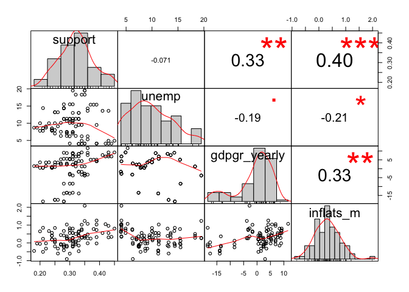

```r
chart.Correlation(ref)
```

## 6.2 Spearmani korrelatsioon

Juhul, kui tunnused on järjestikused, on mõistlik kasutada Spearmani korrelatsiooni, mis ei kasuta korrelatsiooni arvutamiseks algtunnused, vaid annab neile astmeväärtuse (*rank*). Spearmani korrelatsiooni läbiviimiseks võib kasutada juba tuttavat EP 2014 valimiste andmestikku ning usalduse tunnuseid.

```r
usaldus = paneel %>%
  mutate(enne = case_when(!(t1.evalimiste.usaldus %in% 97:98) ~ t1.evalimiste.usaldus),
         parast = case_when(!(t2.evalimiste.usaldus %in% 97:98) ~ t2.evalimiste.usaldus)) %>%
  select(enne,parast) %>%
  na.omit()

corr.test(usaldus, method="spearman")
```

```
Call:corr.test(x = usaldus, method = "spearman")
Correlation matrix
       enne parast
enne   1.00   0.75
parast 0.75   1.00
Sample Size
[1] 835
Probability values (Entries above the diagonal are adjusted for multiple tests.)
       enne parast
enne      0      0
parast    0      0

 To see confidence intervals of the correlations, print with the short=FALSE option
```

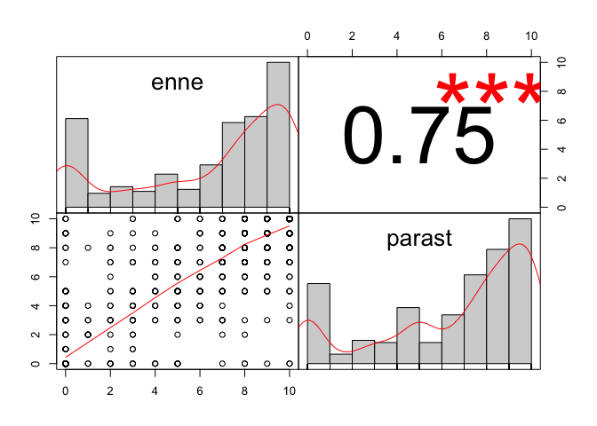

```r
chart.Correlation(usaldus, method="spearman")
```

# 7 Lineaarne regressioon

### 7.0.1 Paketid

```r
library(tidyverse)
library(reshape2)
```

### 7.0.2 Andmestik

```r
df = read.csv("https://martenveskimae.github.io/stat-mod/party_dataset.csv")
```

## 7.1 Mudeli spetsifitseerimine R-is

Mitmed mudelid R-is, sh lineaarse regressiooni mudel, küsivad sisendit valemi kujul. Meenutame näiteks lineaarse regressiooni valemit:

$\hat{y} = \alpha + \beta X + \epsilon$

kus:

- $\hat{y}$ on ennustatav sõltuva tunnuse väärtus;
- $\alpha$ on sõltuva tunnuse väärtus, kui sõltumatud tunnused on null. Tihti tähistatud ka kui $\beta_0$;
- $\beta$ on sõltumatute tunnuste hinnanguline kordaja, teisisõnu hinnanguline mõju suurus;
- $X$ on sõltumatud tunnused;
- $\epsilon$ on viga, mida enamasti käsitletakse juhusliku “mürana” andmetes.

Lineaarse regressiooni jooksutamiseks oleks vaja sisendiks anda nii y kui ka x tunnused, misjärel arvutatakse välja $\alpha$ ja $\beta$ väärtused.

## 7.2 Erakondade toetus ja makromajanduslikud näitajad

Jätkame siinkohal korrelatsioonanalüüsis uuritud tunnustega - erakonna toetus ja töötus. Näitena kasutame taas Reformierakonda. Valemi kujul näeks meie mudel välja järgnev:

$toetus_{ref} = \beta_0 + \beta_1 töötus + \epsilon$

Mudeli spetsifitseerimisel näeks see välja `toetus ~ töötus`, kus `~` sümbol eristab sõltuvat ja sõltumatuid tunnuseid. Lineaarse regressiooni jooksutamiseks kasutame funktsiooni `lm(...)`, kuhu sisendiks läheb valem ning andmestiku nimetus (`data=...`).

Filtreerime andmestikust Reformierakonnaga seotud vaatlused ning kasutame `support` ja `unemp` tunnuseid. Enne analüüsini jõudmist viime veel `support` tunnuse 0 ja 100 vahele, et ühtlustada erinevate tunnuste skaalad ning lihtsustada hilisemat tulemuste tõlgendamist. Lisaks arvutame aastase inflatsiooni, mida kasutame mitmese lineaarse regressiooni näites.

```r
df = df %>%
  mutate(support=support*100,
         inflats_a =((inflats_m_basevalue / inflats_prevyear_base) - 1)*100)

ref = df %>% filter(party=="ref")

ref_mudel = lm(support ~ unemp, data=ref)
ref_mudel
```

```
Call:
lm(formula = support ~ unemp, data = ref)

Coefficients:
(Intercept)        unemp
    27.3345       0.2048
```

Mudeli jooksutamisel kuvatakse $\beta_0$ (Intercept) ja $\beta_1$ (unemp), antud juhul väärtustega 27.335 ja 0.205. Kuna tunnused on nüüd samal protsentuaalsel skaalal, siis saame järeldada, et töötuse 1% suurenedes kasvab Reformierakonna toetus 0.2%. Arvestades, et Reformierakond on olnud pikalt valitsuses, siis võiks eeldada hoopis negatiivset seost - töötuse kasvades langeb valitseva erakonna toetus. Mudeliga tuleks seega veel tööd teha, ent esmalt uurime teisi mudeliga seotud statistikuid.

```r
summary(ref_mudel)
```

```
Call:
lm(formula = support ~ unemp, data = ref)

Residuals:
     Min       1Q   Median       3Q      Max
-12.6659  -5.0756   0.2317   3.7196  16.6618

Coefficients:
            Estimate Std. Error t value Pr(>|t|)
(Intercept)  27.3345     1.6422  16.645   <2e-16 ***
unemp         0.2048     0.1615   1.268    0.208
---
Signif. codes:  0 '***' 0.001 '**' 0.01 '*' 0.05 '.' 0.1 ' ' 1

Residual standard error: 6.772 on 107 degrees of freedom
  (15 observations deleted due to missingness)
Multiple R-squared:  0.01481,   Adjusted R-squared:  0.005599
F-statistic: 1.608 on 1 and 107 DF,  p-value: 0.2075
```

`summary(...)` funktsioon annab meile lisaks $\beta$ väärtuste standard vead ja p-väärtused, ning $R^2$ väärtused. Näeme, et töötuse tunnus ei ole statistiliselt oluline ($\beta_1$ ei erine oluliselt nullist) ning mudeli seletusvõime on vaid 1.5% (*Multiple R-squared*). Ühtlasi näeme viimaselt realt, et kõiki sõltumatuid tunnuseid arvesse võttes pole mudel statistiliselt oluline (p-väärtus: 0.208). Kuna antud juhul kaasasime vaid ühe sõltumatu tunnuse, ei paku see uut teadmist, ent keerulisemate mudelite puhul, kus on mitmeid sõltumatuid tunnuseid, tasub seda jälgida.

Regressioonanalüüsis hinnatakse $\beta$ väärtuste statistilist olulisust t-testi abil, hinnates, kas väärtus on oluliselt erinev nullist. Sellest tulenevalt, mida lähemal on $\beta$ nullile, seda suurem kipub olema tema p-väärtus. Seega, väikeste $\beta$ väärtuste puhul tuleks pidada meeles, et statistiliselt olulise tulemuse saamise tõenäosus on madalam.

Populatsiooni parameetrite suurusi võib muuta, et piltlikustada eelpool kirjeldatud nähtust.

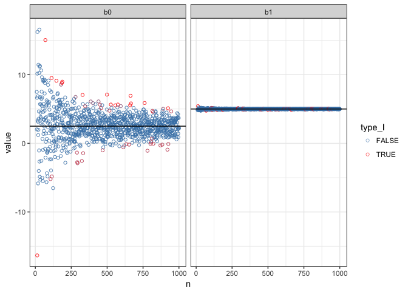

```r
N = 100000          # Populatsiooni suurus
n = 1000            # Valimi ülemine piir
x = rnorm(N,50,15)  # X
e = rnorm(N,0,10)   # Juhuslik viga
b0 = 2.5            # beta 0
b1 = 5              # beta 1
y = b0 + (b1*x) + e # Y

# Loome andmetabeli x ja y väärtustega
pop = data.frame(x = x, y = y)

# Loome funktsiooni, mis väljastab regressiooni tulemused vastavalt valimi suurusele
reg = function(data,n){
  df = data[sample(1:nrow(data), n),]
  m = lm(y~x,data=df)
  data.frame(b0 = m$coefficients[[1]],
             b0l = confint(m)[1,1],
             b0u = confint(m)[1,2],
             b0p = summary(m)$coefficients[,4][[1]],
             b0se = summary(m)$coefficients[,2][[1]],
             b1 = m$coefficients[[2]],
             b1l = confint(m)[2,1],
             b1u = confint(m)[2,2],
             b1p = summary(m)$coefficients[,4][[2]],
             b1se = summary(m)$coefficients[,2][[2]],
             n=n)
}

# Jooksutame regressiooni erinevate valimi suurustega
r = lapply(10:n,function(x)reg(pop,x)) %>% do.call(rbind.data.frame,.)

# Hindame, kas saadud tulemustes esines tüüp I viga (false positive)
b0_pop = reg(pop,N)$b0
b1_pop = reg(pop,N)$b1

r = r %>%
  mutate(b0_typeI = ifelse((b0l > b0_pop | b0u < b0_pop) & b0p <= .05, TRUE, FALSE),
         b1_typeI = ifelse((b1l > b1_pop | b1u < b1_pop) & b1p <= .05, TRUE, FALSE))

# Graafime tulemused
r %>%
  select(n,b0_typeI,b1_typeI,b0,b1) %>%
  melt(c("n","b0_typeI","b1_typeI")) %>%
  melt(c("n","variable","value"),variable.name="TF",value.name="type_I") %>%
  ggplot() +
  geom_point(aes(n,value,color=type_I),shape=1,alpha=.5) +
  geom_hline(data=data.frame(variable=c("b0","b1"),
                             value=c(b0_pop,b1_pop)),
             aes(yintercept=value)) +
  scale_color_manual(values=c("steelblue","red")) +
  facet_wrap(~variable) +
  theme_bw()
```

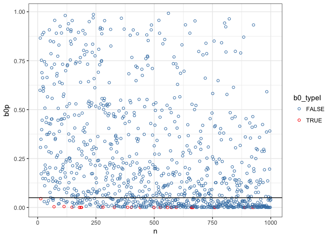

```r
r %>%
  ggplot() +
  geom_point(aes(n,b0p,color=b0_typeI),shape=1) +
  geom_hline(yintercept=0.05) +
  scale_color_manual(values=c("steelblue","red")) +
  theme_bw()
```

```r
# Arvutame, mitmel protsendil juhtudest esines tüüp I viga (eeldada võiks ligemale 5%)
sum(r$b0_typeI==TRUE)/nrow(r)
```

```
[1] 0.02320888
```

```r
sum(r$b1_typeI==TRUE)/nrow(r)
```

```
[1] 0.04339051
```

Tihti kasutatakse mudeli hindamiseks veel ruutkeskmist hälvet (*mean squared error* ehk MSE), mis väljendab, kui hästi suudab mudel ennustada sõltuva tunnuse väärtuseid. MSE leidmiseks tuleb lahutada õigetest väärtustest ennustatud väärtused (ehk arvutada ennustusjäägid), võtta need ruutu ning leida saadud jada keskmine. Seda on lihtne teha, kuivõrd mudel pakub ennustusjääke `$residuals` abil.

```r
mean(ref_mudel$residuals^2)
```

```
[1] 45.01441
```

Kui soovime näha mudeli ennustatud väärtusi, siis on selleks funktsioon `predict(...)`, kuhu läheb argumendiks mudel ning soovi korral andmestik uute andmetega.

```r
yhat = predict(ref_mudel)
head(yhat)
```

```
       1        2        3        4        5        6
28.42012 28.33819 28.33819 28.33819 28.17432 28.17432
```

Sarnase mudeli võib teha ka teiste erakondade kohta. Võtame näiteks Keskerakonna.

```r
kesk = df %>% filter(party=="kesk")

kesk_mudel = lm(support ~ unemp, data=kesk)
summary(kesk_mudel)
```

```
Call:
lm(formula = support ~ unemp, data = kesk)

Residuals:
    Min      1Q  Median      3Q     Max
-7.1163 -2.3599 -0.3058  2.1375  9.5876

Coefficients:
            Estimate Std. Error t value Pr(>|t|)
(Intercept) 24.53591    0.82636  29.692   <2e-16 ***
unemp        0.11844    0.08128   1.457    0.148
---
Signif. codes:  0 '***' 0.001 '**' 0.01 '*' 0.05 '.' 0.1 ' ' 1

Residual standard error: 3.408 on 107 degrees of freedom
  (15 observations deleted due to missingness)
Multiple R-squared:  0.01946,   Adjusted R-squared:  0.0103
F-statistic: 2.124 on 1 and 107 DF,  p-value: 0.148
```

Tulemus on suuresti sama.

Mudeli tulemuste mugavaks esitamiseks on loodud pakett **stargazer**. Stargazer võimaldab esitada nii lineaarse regressiooni kui mitmete teiste mudelite tulemusi kujul, mis on aktsepteeritav enamikes teadusajakirjades. Stargazeri võimalustega tutvumiseks saab infot järgnevalt lingilt: [Stargazer cheatsheet](http://www.jakeruss.com/cheatsheets/stargazer/).

```r
library(stargazer)

# type võimalikud väärtused on "text", "html" ja "latex", vastavalt soovitud väljundi formaadile (text, html ja pdf)
stargazer(ref_mudel, kesk_mudel,
          title="Linear regression table",
          covariate.labels="Unemployment",
          dep.var.labels="Support",
          column.labels=c("Ref", "Kesk"),
          model.numbers=F,
          no.space=T,
          star.cutoffs=c(0.05,0.01,0.001),
          type="html")
```

**Linear regression table**

|  | *Dependent variable:* |  |
| --- | --- | --- |
|  | Support |  |
|  | Ref | Kesk |
| Unemployment | 0.205 | 0.118 |
|  | (0.162) | (0.081) |
| Constant | 27.335*** | 24.536*** |
|  | (1.642) | (0.826) |
| Observations | 109 | 109 |
| R<sup>2</sup> | 0.015 | 0.019 |
| Adjusted R<sup>2</sup> | 0.006 | 0.010 |
| Residual Std. Error (df = 107) | 6.772 | 3.408 |
| F Statistic (df = 1; 107) | 1.608 | 2.124 |
| *Note:* | p<0.05; p<0.01; p<0.001 |  |

## 7.3 Mitmene lineaarne regressioon

Lineaarset regressiooni kasutades ei pea piirduma vaid ühe tunnuse lisamisega, vaid see võimaldab hinnata mitmeid tunnuseid korraga (oluline eelis t-testi ja korrelatsiooni ees). Lisame varasemale mudelile SKT kasvu ja inflatsiooni tunnused:

$toetus_{ref} = \beta_0 + \beta_1 töötus + \beta_2 SKT + \beta_3 inflatsioon + \epsilon$

```r
ref = ref %>% filter(year>=2011, year<2015)

mlr_mudel = lm(support ~ unemp + gdpgr_yearly + inflats_a, data=ref)
summary(mlr_mudel)
```

```
Call:
lm(formula = support ~ unemp + gdpgr_yearly + inflats_a, data = ref)

Residuals:
    Min      1Q  Median      3Q     Max
-6.2222 -2.3461  0.6219  1.5866 11.2140

Coefficients:
             Estimate Std. Error t value Pr(>|t|)
(Intercept)   29.9480     3.8262   7.827 8.35e-10 ***
unemp         -0.8965     0.5845  -1.534    0.132
gdpgr_yearly   1.8274     0.3438   5.315 3.59e-06 ***
inflats_a     -0.3587     0.4936  -0.727    0.471
---
Signif. codes:  0 '***' 0.001 '**' 0.01 '*' 0.05 '.' 0.1 ' ' 1

Residual standard error: 3.535 on 43 degrees of freedom
  (1 observation deleted due to missingness)
Multiple R-squared:  0.4927,    Adjusted R-squared:  0.4573
F-statistic: 13.92 on 3 and 43 DF,  p-value: 1.761e-06
```

Tulemused näitavad, et SKT kasv on statistiliselt oluline ning märkimisväärse mõjuga. Samuti kasvas mudeli seletusvõime 46%ni (*Adjusted R-squared*) ning mudel ise on statistiliselt oluline.

```r
mean(mlr_mudel$residuals^2)
```

```
[1] 11.43551
```

Mudeli ruutkeskmine hälve on samuti oluliselt vähenenud võrreldes eelnevaga.

Kui võtta eesmärgiks saada võimalikult hea mudeli sobivus, võib kaaluda sõltumatute tunnuste transformeerimist, eeldusel, et see on teoreetiliselt põhjendatud. Seega tuleks küsida, milline funktsionaalne vorm võiks antud sõltumatutel tunnustel peale lineaarse vormi olla. Visualiseerime seosed.

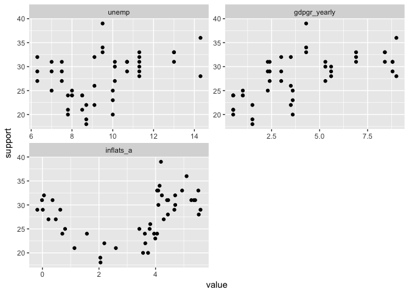

```r
ref %>%
  melt("support",c("unemp","gdpgr_yearly","inflats_a")) %>%
  ggplot() +
  geom_point(aes(value,support)) +
  coord_fixed() +
  facet_wrap(~variable,scales="free",ncol=2)
```

Antud juhul võib jätta töötuse lineaarseks, SKT kasvu puhul katsetada logaritmimist ning inflatsiooni puhul kasutada ruutseost. Loome uued transformeeritud tunnused, ning vaatame, kas seos erakonna toetusega on muutunud lineaarsemaks.

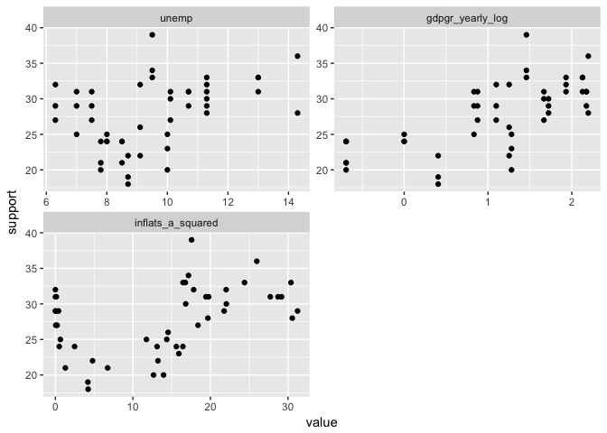

```r
ref = ref %>%
  mutate(gdpgr_yearly_log = log(gdpgr_yearly),
         inflats_a_squared = inflats_a^2)

ref %>%
  melt("support",c("unemp","gdpgr_yearly_log","inflats_a_squared")) %>%
  ggplot() +
  geom_point(aes(value,support)) +
  coord_fixed() +
  facet_wrap(~variable,scales="free",ncol=2)
```

Tundub, et on olnud abi ning võime teha uue mudeli transformeeritud tunnustega.

```r
mlr_mudel_tr = lm(support ~ unemp + gdpgr_yearly_log + inflats_a + inflats_a_squared, data=ref)
summary(mlr_mudel_tr)
```

```
Call:
lm(formula = support ~ unemp + gdpgr_yearly_log + inflats_a +
    inflats_a_squared, data = ref)

Residuals:
    Min      1Q  Median      3Q     Max
-6.9753 -1.9009 -0.3334  1.8826 10.5300

Coefficients:
                  Estimate Std. Error t value Pr(>|t|)
(Intercept)        29.0877     3.8250   7.605 2.01e-09 ***
unemp              -0.3867     0.5140  -0.752  0.45602
gdpgr_yearly_log    3.0627     0.9127   3.356  0.00169 **
inflats_a          -2.5772     1.2790  -2.015  0.05033 .
inflats_a_squared   0.5346     0.2694   1.984  0.05379 .
---
Signif. codes:  0 '***' 0.001 '**' 0.01 '*' 0.05 '.' 0.1 ' ' 1

Residual standard error: 3.481 on 42 degrees of freedom
  (1 observation deleted due to missingness)
Multiple R-squared:  0.5195,    Adjusted R-squared:  0.4738
F-statistic: 11.35 on 4 and 42 DF,  p-value: 2.461e-06
```

```r
mean(mlr_mudel_tr$residuals^2)
```

```
[1] 10.83034
```

Mudeli parameetrites on näha väikest arengut. Edasi tuleks anda põhjalikum hinnang mudeli toimimisele.

## 7.4 Mudeli hindamine

Kõige kiirema ülevaate võimalikest probleemidest saab ennustusjääkide visualiseerimisel.

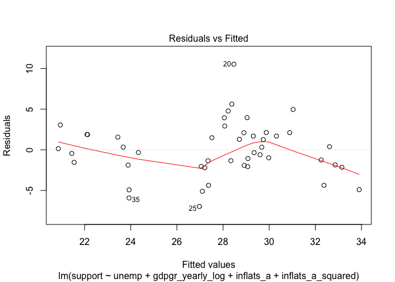

```r
plot(mlr_mudel_tr, which=1) # Rohkem joonised ennustusjääkidest saab jättes 'which' täpsustamata
```

Ennustusjääkide puhul soovime näha, et need oleksid jaotunud ühtlase hajususega ümber nulli. Antud juhul on näha, et ennustusjäägid on siiski teatud määral süstemaatiliselt kaldu, mis viitab probleemidele mudeli funktsionaalses vormis. Samas heteroskedastiivsust ei paista eriti olevat.

Mudeli funktsionaalse vormi hindamiseks kasutatakse tihti Ramsey RESET-testi, mis lisab mudelile regressorite ruutseosed ning hindab, kas see on algmudelist parem. Kasutame selleks funktsiooni `resettest(...)` paketist **lmtest**.

```r
library(lmtest)
resettest(mlr_mudel, power=2, type="fitted")
```

```
    RESET test

data:  mlr_mudel
RESET = 6.2981, df1 = 1, df2 = 42, p-value = 0.01603
```

```r
resettest(mlr_mudel_tr, power=2, type="fitted")
```

```
    RESET test

data:  mlr_mudel_tr
RESET = 2.4592, df1 = 1, df2 = 41, p-value = 0.1245
```

Antud juhul viitavad tulemused, et ilma transformeeritud tunnusteta mudelil oli halvem funktsionaalne vorm kui transformeeritud tunnustega mudelil. Transformeeritud tunnustega mudel ei muutu oluliselt paremaks, kui lisada ruutseostega tunnused. Samas võib RESET testi tulemus olla oluline kuupseoste (argument `power=2:3`) korral, kuivõrd visuaalselt oli näha ennustusjääkide teatud süstemaatilist kõikumist ümber nulli.

Heteroskedastiivsuse hindamiseks on populaarsemad White test ja Breusch-Pagan test, millest võib antud juhul katsetada viimasega. Breusch-Pagani testi puhul sobitatakse uus mudel algmudeli ennustusjääkidele ning hinnatakse, kas sealt ilmnevad olulised seosed. **lmtest** paketist on selleks funktsioon `bptest(...)`.

```r
bptest(mlr_mudel_tr)
```

```
    studentized Breusch-Pagan test

data:  mlr_mudel_tr
BP = 5.2184, df = 4, p-value = 0.2656
```

Kuna antud juhul osutus test statistiliselt ebaoluliseks, võib järeldada, et heteroskedastiivsusega olulisi probleeme pole.

Viimaks võime kontrollida, ega uute tunnuste lisamisel pole mudelis ilmnenud multikollineaarsust. Multikollineaarsuse korral on sõltumatud tunnused on omavahel tugevas korrelatsioonis, mistõttu on raske eristada üksikute tunnuste mõju (korrelatsioonist tingituna, kui üks väärtus kasvab, kasvavad ka teised väärtused ning üksikud mõjud pole enam eristatavad). Sellest tulenevalt pole hinnatud parameetrid ($\beta$ väärtused) enam usaldatavad. Kuigi teatud korrelatsioon esineb tunnuste vahel peaaegu alati, on oluline, et sõltumatute tunnuste omavaheline korrelatsioon ei ületaks sõltumatu ja sõltuva tunnuse korrelatsiooni.

Regressioonanalüüsi korral on multikollineaarsuse hindamiseks kasutusel VIF (*Variance Inflation Factor*) test. VIF test hindab, kui suur oli sõltumatu tunnuse $\beta_k$ variatsioon teiste sõltumatute tunnuste kontekstis ($Var(\beta_k)$) ja kui suur isoleeritult ($Var_{min}(\beta_k)$). Seejärel jagab ta esimese teisega $\frac{Var(\beta_k)}{Var_{min}(\beta_k)} = \frac{1}{1-R_k^2}$. Üldjuhul leitakse, et kui tulemus on üle kümne, võib mudelis esineda multikollineaarsuse probleem.

VIF testi funktsiooni `vif(...)` saame paketist **HH**. Kuna **HH** ja **tidyiverse** pakettides on osa funktsioone sama nimega, siis ei hakka praegu **HH-d** eraldi aktiveerima, vaid rakendame sealt ainult hetkel soovitud `vif` funktsiooni.

```r
HH::vif(mlr_mudel_tr)
```

```
            unemp  gdpgr_yearly_log         inflats_a inflats_a_squared
         4.155656          2.647484         20.732871         27.740997
```

Antud mudeli puhul on probeelm inflatsiooni ja inflatsioon ruudus tunnustega, mis on samas ootuspärane tulemus (võimegi eeldada tugevat seost antud kahe tunnuse vahel)

```r
HH::vif(mlr_mudel)
```

```
       unemp gdpgr_yearly    inflats_a
    5.210994     3.358901     2.994678
```

Transformeerimata tunnustega mudelis sellist probleemi ei esinenud ning ilmselt oleksid selle tulemused kokkuvõttes usaldusväärsemad.

# 8 Logistiline regressioon

### 8.0.1 Paketid

```r
library(tidyverse)
library(stargazer)
library(caret)
```

### 8.0.2 Andmestik

```r
RK_2015 = read.csv("https://martenveskimae.github.io/stat-mod/RK_2015.csv")
```

## 8.1 Üldistatud lineaarne mudel (*generalized linear model*)

Eelnevalt käsitletud lineaarse regressiooni mudeli üheks peamiseks eelduseks oli, et ennustusjäägid peavad olema normaaljaotuslikud. Tuleb aga välja, et taolist lineaarset mudelit on võimalik üldistada ning eeldada seejuures väga erinevate jaotustega ennustusjääke (ennustusjäägid peavad olema [eksponentide perekonnast](https://en.wikipedia.org/wiki/Exponential_family)). See võimaldab ühe tüüpmudeli abil modelleerida näiteks pidevtunnustega andmeid (normaaljaotus), loendusandmeid (Poissooni jaotus), eksponentseoseid, kui ka binaarseid andmeid (Bernoulli jaotus). Mudeli funktsionaalne vorm on järgnev:

$E(y)=g^{-1}(X\beta)$

kus:

- $E(y)$ on keskmine sõltuvtunnuse väärtus sõltuvalt $X$ väärtustest;
- $X\beta$ X on sõltumatud tunnused korrutatuna hinnatava parameetriga $\beta$;
- $g$ on tõenäosuse funktsioon, mille abil seotakse keskmine sõltuvtunnuse väärtus sõltumatute tunnustega $X\beta$ (*link function*)

Antud juhul keskendume jah/ei jaotusele ehk Bernoulli jaotusele, kus

$g(\mu) = X\beta = ln\big(\frac{\mu}{1-\mu}\big)$ ja

$\mu = \frac{1}{1+exp(-X\beta)}$

Logistiline regressioon on olemuselt lineaarne klassifikaator, st ta sobitab kahe klassi vahele lineaarse eralduspiiri. Selle visualiseerimiseks võib teha simulatsiooni, kus võrdleme logistilist regressiooni mõne tuntuma mitte-lineaarse klassifikaatoriga (juhumets ehk *random forest* ja tugivektormasin ehk *support vector machine*).

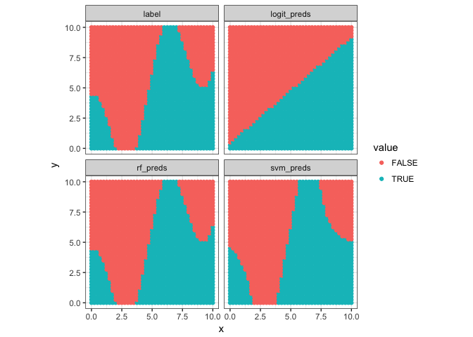

```r
library(randomForest)
library(e1071)

cos_func = function(x,y){
  set.seed(200212)
  x > y + cos(x)*rnorm(1,0,2)
}
pr = function(x) predict(x,test) %>% as.numeric() -1

data = expand.grid(x=seq(0,10,.25),
                   y=seq(0,10,.25)) %>%
  mutate(label = cos_func(x,y))

log_fit = glm(label~.,data=data,family=binomial,control=glm.control(maxit=20))
rf_fit = randomForest(label~.,data=data,mtry=2)
svm_fit = svm(factor(label)~.,data=data,kernel="radial",probability=T,cost=5)

data %>%
  mutate(logit_preds = predict(log_fit,data,"response")>.5,
         rf_preds = predict(rf_fit,data,"response")>.5,
         svm_preds = predict(svm_fit,data)) %>%
  reshape2::melt(c("x","y")) %>%
  ggplot() +
  geom_point(aes(x,y,color=value)) +
  coord_fixed() +
  facet_wrap(~variable) +
  theme_bw()
```

## 8.2 Valimisosaluse analüüsimine

Valimisosalust mõõdetakse indiviiditasandil enamasti binaarsel kujul - kas vastaja hääletas või mitte. Kui soovime seda modelleerida, siis saame arvutada küsitlusele vastaja tõenäosuse (0-1) kuuluda kas ühte või teise rühma.

Valimisosaluse analüüsiks võtame ette 2015. aasta Riigikogu valimiste küsitluse ning püüame ennustada inimeste valimisosalust sotsiaal-demograafiliste tunnuste abil. Järjestame esmalt ordinaalsed tunnused ja tutvume andmestikuga.

```r
palgad = c("Alla 200 €","200–275 €","276–350 €","351–425 €","426–500 €","501–575 €",
           "576–700 €","701–1000 €","1001–1300 €","1301–1600 €","1601–1900 €",
           "1901–2200 €","2201–2500 €","Üle 2500 €")
haridus = c("Põhiharidus","Keskharidus","Kõrgharidus")
RK_2015$wage = factor(RK_2015$wage,levels=palgad)
RK_2015$education = factor(RK_2015$education,levels=haridus)

summary(RK_2015)
```

```
            vote          age          gender          education
 Ei hääletanud:150   Min.   :18.00   Mees :350   Põhiharidus:118
 Hääletas     :646   1st Qu.:37.00   Naine:446   Keskharidus:417
                     Median :53.00               Kõrgharidus:261
                     Mean   :51.97
                     3rd Qu.:67.00
                     Max.   :90.00

          ethnicity            wage
 Eestlane      :653   701–1000 € :143
 Mitte-eestlane:143   576–700 €  :123
                      276–350 €  : 96
                      1301–1600 €: 80
                      1001–1300 €: 78
                      351–425 €  : 72
                      (Other)    :204
```

Sõltuvtunnus on antud hetkel `vote`, mille puhul näeme, et 646 küsitletutest hääletas ja 150 ei hääletanud. Viime läbi logistilise regressiooni kõikide andmestikus kaasatud tunnustega. Logistilise regressiooni jaoks kasutame funktsiooni `glm(...)`, kus tuleb lisaks valemile ja andmestikule märkida ennustusjääkide perekond `family=binominal`.

```r
f = formula(vote ~ age + I(age^2) + gender + education + ethnicity + as.numeric(wage))
osalus_mudel = glm(f, data= RK_2015, family=binomial)
summary(osalus_mudel)
```

```
Call:
glm(formula = f, family = binomial, data = RK_2015)

Deviance Residuals:
    Min       1Q   Median       3Q      Max
-2.3317   0.3497   0.5297   0.6659   1.4727

Coefficients:
                          Estimate Std. Error z value Pr(>|z|)
(Intercept)             -1.537e+00  7.877e-01  -1.951 0.051055 .
age                      3.143e-02  3.188e-02   0.986 0.324268
I(age^2)                -2.829e-05  3.184e-04  -0.089 0.929201
genderNaine             -8.873e-02  1.950e-01  -0.455 0.649071
educationKeskharidus     8.422e-01  2.441e-01   3.449 0.000562 ***
educationKõrgharidus     1.626e+00  3.057e-01   5.318 1.05e-07 ***
ethnicityMitte-eestlane  5.732e-03  2.471e-01   0.023 0.981495
as.numeric(wage)         9.712e-02  3.544e-02   2.740 0.006141 **
---
Signif. codes:  0 '***' 0.001 '**' 0.01 '*' 0.05 '.' 0.1 ' ' 1

(Dispersion parameter for binomial family taken to be 1)

    Null deviance: 770.46  on 795  degrees of freedom
Residual deviance: 710.26  on 788  degrees of freedom
AIC: 726.26

Number of Fisher Scoring iterations: 5
```

Et saada kätte lihtsamini tõlgendatavad šansside suhted, tuleb $\beta$ väärtused eksponentida. $\beta$ väärtused saame funktsiooniga `coef()` ning eksponendid `exp(...)`.

```r
(or = exp(coef(osalus_mudel)))
```

```
            (Intercept)                     age                I(age^2)
              0.2150577               1.0319259               0.9999717
            genderNaine    educationKeskharidus    educationKõrgharidus
              0.9150965               2.3213569               5.0810969
ethnicityMitte-eestlane        as.numeric(wage)
              1.0057483               1.1019953
```

Šansside suhet ei saa siiski lineaarselt tõlgendada, sest konkreetne šansi suurus sõltub X väärtustest. Üks viis, kuidas kõikide X peale keskmist mõju suurust väljendada, on leida keskmine marginaalefekt. Selleks tuleb leida esmalt keskmine logaritm-suhte tihedus ning korrutada see koefitsientide suurustega. Kui see tundub praegu keeruline, siis antud hetkel ei olegi tarvis seda mõista. Huvi korral võib alustada tõenäosuse ja logaritm-suhte uurimist siit: [Binary Outcome GLM Plots](http://thomasleeper.com/Rcourse/Tutorials/binaryglmplots.html).

```r
(ame = mean(dlogis(predict(osalus_mudel, type="link"))) * coef(osalus_mudel))
```

```
            (Intercept)                     age                I(age^2)
          -2.163208e-01            4.423521e-03           -3.981973e-06
            genderNaine    educationKeskharidus    educationKõrgharidus
          -1.248868e-02            1.185380e-01            2.288028e-01
ethnicityMitte-eestlane        as.numeric(wage)
           8.067866e-04            1.367057e-02
```

Kui šansside suhet võis mõista “kui palju kasvab sündmuse šanss ($\frac{y=1}{y=0}$) X-i kasvades ühe võrra” (mitte segi ajada riskisuhtega ($\frac{y=1}{y}$)!), siis keskmine marginaalefekt tähistab regressiooni joone keskmist kallakut.

Kuvame kõik leitud väärtused ühes tabelis kasutades selleks **stargazerit**.

```r
stargazer(osalus_mudel,osalus_mudel,osalus_mudel,
          dep.var.labels = "Hääletas valimistel",
          column.labels = c("Beta koefitsiendid",
                            "Šansside suhe",
                            "Keskmine marginaalefekt"),
          dep.var.caption = "",
          coef = list(NULL, or, ame),
          type="text")
```

```
================================================================================
                                          Hääletas valimistel
                        Beta koefitsiendid Šansside suhe Keskmine marginaalefekt
                               (1)              (2)                (3)
--------------------------------------------------------------------------------
age                           0.031          1.032***             0.004
                             (0.032)          (0.032)            (0.032)

I(age2)                      -0.00003        1.000***           -0.00000
                             (0.0003)        (0.0003)           (0.0003)

genderNaine                   -0.089         0.915***            -0.012
                             (0.195)          (0.195)            (0.195)

educationKeskharidus         0.842***        2.321***             0.119
                             (0.244)          (0.244)            (0.244)

educationKõrgharidus         1.626***        5.081***             0.229
                             (0.306)          (0.306)            (0.306)

ethnicityMitte-eestlane       0.006          1.006***             0.001
                             (0.247)          (0.247)            (0.247)

as.numeric(wage)             0.097***        1.102***             0.014
                             (0.035)          (0.035)            (0.035)

Constant                     -1.537*           0.215             -0.216
                             (0.788)          (0.788)            (0.788)

--------------------------------------------------------------------------------
Observations                   796              796                796
Log Likelihood               -355.130        -355.130           -355.130
Akaike Inf. Crit.            726.259          726.259            726.259
================================================================================
Note:                                                *p<0.1; **p<0.05; ***p<0.01
```

Arvutame viimaks McFaddeni pseudo R-ruudu suuruse. Arvestada tuleks, et erinevalt lineaarse regressiooni R-ruudust, on antud pseudo R-ruudu suurus alati madalam (0.2-0.4 on juba hea tulemus).

$R^2=1-\frac{logLik_{mod}}{logLik_{null}}$

```r
1 - osalus_mudel$deviance / osalus_mudel$null.deviance
```

```
[1] 0.07813415
```

Meenutame, et andmestikus on hääletanuid oluliselt rohkem kui mittehääletanuid. Mudelit saaks seega oluliselt parandada tasakaalustatud andmestikuga. Kasutame selleks paketti **ROSE** ja funktsiooni `ovun.sample(...)`.

```r
library(ROSE)
over = ovun.sample(vote~.,data=RK_2015,method="over",N=1292)$data
under = ovun.sample(vote~.,data=RK_2015,method="under",N=300)$data
both = ovun.sample(vote~.,data=RK_2015,method="both",p=.5,N=nrow(RK_2015))$data

osalus_over = glm(f, data=over, family=binomial)
osalus_under = glm(f, data=under, family=binomial)
osalus_both = glm(f, data=both, family=binomial)

1 - osalus_over$deviance / osalus_over$null.deviance
```

```
[1] 0.09199129
```

```r
1 - osalus_under$deviance / osalus_under$null.deviance
```

```
[1] 0.1095839
```

```r
1 - osalus_both$deviance / osalus_both$null.deviance
```

```
[1] 0.08872341
```

Hea. Pseudo R-ruut tõusis tasakaalustatud andmetega mõne protsendi võrra.

## 8.3 Mudeli hindamine

### 8.3.1 Klassifikatsioonitabel

```r
logit_preds = ifelse(predict(osalus_mudel,type="response")>.5,"Hääletas","Ei hääletanud")
confusionMatrix(logit_preds,RK_2015$vote)
```

```
Confusion Matrix and Statistics

               Reference
Prediction      Ei hääletanud Hääletas
  Ei hääletanud             9        7
  Hääletas                141      639

               Accuracy : 0.8141
                 95% CI : (0.7853, 0.8405)
    No Information Rate : 0.8116
    P-Value [Acc > NIR] : 0.4496

                  Kappa : 0.0748
 Mcnemar's Test P-Value : <2e-16

            Sensitivity : 0.06000
            Specificity : 0.98916
         Pos Pred Value : 0.56250
         Neg Pred Value : 0.81923
             Prevalence : 0.18844
         Detection Rate : 0.01131
   Detection Prevalence : 0.02010
      Balanced Accuracy : 0.52458

       'Positive' Class : Ei hääletanud
```

### 8.3.2 ROC-kõver

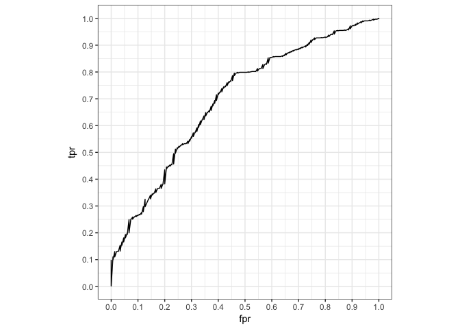

```r
ROC_curve = function(probs,response,cut=.5){
  cutoffs = sort(unique(as.numeric(probs)))
  tpr = sapply(cutoffs, function(cut) sum((probs >= cut) == T & response == "Hääletas")/(sum(response == "Hääletas")))
  fpr = sapply(cutoffs, function(cut) sum((probs >= cut) == T & response == "Ei hääletanud")/(sum(response == "Ei hääletanud")))
  stats = data.frame(cutoffs, tpr, fpr)

  stats %>%
    ggplot() +
    geom_line(aes(x = fpr, y = tpr)) +
    scale_x_continuous(breaks=seq(0,1,.1)) +
    scale_y_continuous(breaks=seq(0,1,.1)) +
    coord_fixed() +
    theme_bw()
}

ROC_curve(predict(osalus_mudel,type="response"), RK_2015$vote)
```